# Analisis Cakupan Imunisasi dan Kasus Campak Menurut Provinsi di Indonesia Tahun 2024

Adit Nurdiansyah

2026-03-12

## Install dan Load Library

Beberapa library yang perlu diinstall sebagai berikut:

```r
## Install library jika belum tersedia (hapus tanda # untuk menginstall):
#install.packages("ggplot2")
#install.packages("readxl")
#install.packages("ggthemes")
#install.packages("gridExtra")
#install.packages("dplyr")
#install.packages("scales")
#install.packages("ggpubr")

## Setelah library terinstall, lalu Run Chunk
## Kemudian hapus atau beri komentar kembali
## Terakhir aktifkan library:
library(ggplot2)
library(readxl)
library(ggthemes)
library(gridExtra)
library(dplyr)
library(scales)
library(ggpubr)
```

## Input Data

Data diinput dari Microsoft Excel dengan syntax sebagai berikut:

```r
# Sesuaikan path file dengan directory Anda
setwd("C:/Adit Nurdiansyah/Kuliah/Semester/Semester 2 - Genap (2025-2026)/MK Probabilitas dan Statistika/Tugas/Kelompok/Pertemuan 3")
data <- read_excel("data_campak_indonesia_2024.xlsx")

# Bersihkan data: hapus baris kosong
data <- data[!is.na(data$Provinsi), ]

# Konversi tipe data
data$`Cakupan MR2 %` <- as.numeric(data$`Cakupan MR2 %`)
data$`Jumlah Kasus Campak` <- as.numeric(data$`Jumlah Kasus Campak`)

# Tampilkan 6 baris pertama
head(data)
```

```
## # A tibble: 6 × 4
##   Provinsi         `Pulau/Wilayah` `Cakupan MR2 %` `Jumlah Kasus Campak`
##   <chr>            <chr>                     <dbl>                 <dbl>
## 1 DKI Jakarta      Jawa                      106.                   8206
## 2 Jawa Tengah      Jawa                      102.                  32512
## 3 Banten           Jawa                       98.5                 10436
## 4 Sumatera Selatan Sumatera                   97.4                   432
## 5 DI Yogyakarta    Jawa                       95.9                  3399
## 6 Sulawesi Selatan Sulawesi                   91.6                  5670
```

```r
# Tampilkan ringkasan struktur data
str(data)
```

```
## tibble [38 × 4] (S3: tbl_df/tbl/data.frame)
##  $ Provinsi           : chr [1:38] "DKI Jakarta" "Jawa Tengah" "Banten" "Sumatera Selatan" ...
##  $ Pulau/Wilayah      : chr [1:38] "Jawa" "Jawa" "Jawa" "Sumatera" ...
##  $ Cakupan MR2 %      : num [1:38] 105.8 101.6 98.5 97.3 95.9 ...
##  $ Jumlah Kasus Campak: num [1:38] 8206 32512 10436 432 3399 ...
```

## 1. Pie Chart

Dari data tersebut akan disajikan visualisasi data dalam bentuk Pie Chart. Berikut terlampir hasil visualisasi **Distribusi Jumlah Kasus Campak Berdasarkan Wilayah**:

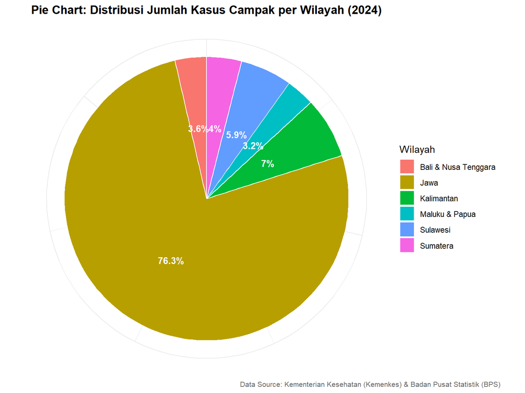

```r
# Agregasi total kasus per wilayah
data_wilayah <- data %>%
  group_by(`Pulau/Wilayah`) %>%
  summarise(Total_Kasus = sum(`Jumlah Kasus Campak`, na.rm = TRUE)) %>%
  mutate(Persentase = round((Total_Kasus / sum(Total_Kasus)) * 100, 1))

pie_chart <- ggplot(data_wilayah, aes(x = "", y = Total_Kasus, fill = `Pulau/Wilayah`)) +
  geom_bar(stat = "identity", width = 1, color = "white") +
  coord_polar("y", start = 0) +
  theme_minimal() +
  labs(
    title = "Pie Chart: Distribusi Jumlah Kasus Campak per Wilayah (2024)",
    fill  = "Wilayah",
    caption = "Data Source: Kementerian Kesehatan (Kemenkes) & Badan Pusat Statistik (BPS)"
  ) +
  geom_text(
    aes(label = paste0(Persentase, "%")),
    position = position_stack(vjust = 0.5),
    size = 3.5, color = "white", fontface = "bold"
  ) +
  theme(
    axis.text.x  = element_blank(),
    axis.title   = element_blank(),
    plot.title   = element_text(hjust = 0.5, face = "bold", size = 13),
    plot.caption          = element_text(hjust = 1, size = 8, color = "gray40"),
    plot.caption.position = "plot"
  )

pie_chart
```

### Interpretasi Pie Chart

**Statistik Deskriptif:** Berdasarkan hasil Pie Chart di atas, distribusi jumlah kasus campak di Indonesia tahun 2024 menunjukkan bahwa wilayah Jawa mendominasi dengan proporsi terbesar. Hal ini dikarenakan Jawa merupakan wilayah dengan kepadatan penduduk tertinggi di Indonesia, sehingga potensi penyebaran penyakit campak lebih besar dibandingkan wilayah lain.

**Statistik Inferensia:** Dominasi kasus di wilayah Jawa mengindikasikan adanya ketidakmerataan distribusi kasus campak antara wilayah Jawa dan luar Jawa. Secara deskriptif, temuan ini memberikan dasar untuk menyimpulkan bahwa wilayah Jawa memerlukan intervensi imunisasi yang lebih intensif dan terstruktur.

## 2. Bar Chart

Dari data tersebut akan disajikan visualisasi data dalam bentuk Bar Chart. Berikut terlampir hasil visualisasi **Jumlah Kasus Campak per Provinsi Tahun 2024**:

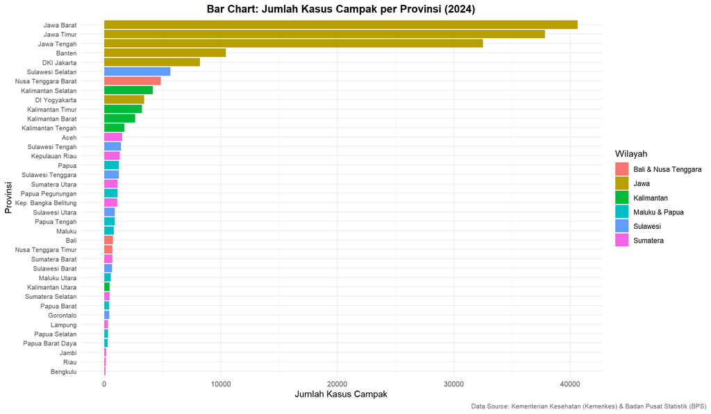

```r
bar_chart <- ggplot(data, aes(x = reorder(Provinsi, `Jumlah Kasus Campak`),
                              y = `Jumlah Kasus Campak`,
                              fill = `Pulau/Wilayah`)) +
  geom_bar(stat = "identity") +
  coord_flip() +
  theme_minimal() +
  labs(
    title = "Bar Chart: Jumlah Kasus Campak per Provinsi (2024)",
    x     = "Provinsi",
    y     = "Jumlah Kasus Campak",
    fill  = "Wilayah",
    caption = "Data Source: Kementerian Kesehatan (Kemenkes) & Badan Pusat Statistik (BPS)"
  ) +
  theme(
    plot.title  = element_text(hjust = 0.5, face = "bold", size = 13),
    axis.text.y = element_text(size = 8),
    plot.caption          = element_text(hjust = 1, size = 8, color = "gray40"),
    plot.caption.position = "plot"
  )

bar_chart
```

### Interpretasi Bar Chart

**Statistik Deskriptif:** Grafik Bar Chart menunjukkan perbandingan jumlah kasus campak di setiap provinsi pada tahun 2024. Setiap batang merepresentasikan jumlah kasus pada suatu provinsi dan diurutkan dari jumlah kasus terendah hingga tertinggi.

**Statistik Inferensia:** Dari grafik ini dapat terlihat bahwa terdapat perbedaan jumlah kasus campak antar provinsi. Beberapa provinsi memiliki jumla jumlah kasus yang relatif tinggi dibandingkan provinsi lainnya. Hal ini dapat disebabkan oleh berbagai faktor seperti kepadatan penduduk, tingkat cakupan imunisasi, serta akses terhadap layanan kesehatan.

## 3. Histogram

Dari data tersebut akan disajikan visualisasi data dalam bentuk Histogram. Berikut terlampir hasil visualisasi **Distribusi Frekuensi Cakupan Imunisasi MR2 (%)** pada seluruh provinsi:

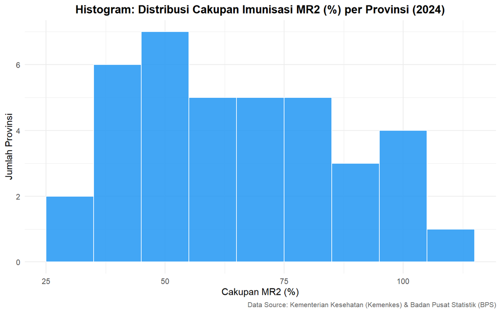

```r
histogram <- ggplot(data, aes(x = `Cakupan MR2 %`)) +
  geom_histogram(binwidth = 10, fill = "#2196F3", color = "white", alpha = 0.85) +
  theme_minimal() +
  labs(
    title = "Histogram: Distribusi Cakupan Imunisasi MR2 (%) per Provinsi (2024)",
    x     = "Cakupan MR2 (%)",
    y     = "Jumlah Provinsi",
    caption = "Data Source: Kementerian Kesehatan (Kemenkes) & Badan Pusat Statistik (BPS)"
  ) +
  theme(
    plot.title = element_text(hjust = 0.5, face = "bold", size = 13),
    plot.caption          = element_text(hjust = 1, size = 8, color = "gray40"),
    plot.caption.position = "plot"
  )

histogram
```

### Interpretasi Histogram

**Statistik Deskriptif:** Dari histogram dapat dilihat bagaimana penyebaran nilai cakupan imunisasi pada berbagai provinsi. Jika sebagian besar batang histogram terkonsentrasi pada nilai tertentu, maka dapat disimpulkan bahwa banyak provinsi memiliki tingkat cakupan imunisasi yang berada pada rentang tersebut.

**Statistik Inferensia:** Grafik ini membantu memahami apakah cakupan imunisasi antar provinsi cenderung merata atau masih terdapat perbedaan yang cukup besar. Selain itu, histogram juga dapat menunjukkan apakah terdapat provinsi dengan cakupan imunisasi yang sangat rendah atau sangat tinggi dibandingkan provinsi lainnya.

## 4. Density Plot

Dari data tersebut akan disajikan visualisasi data dalam bentuk Density Plot. Berikut terlampir hasil visualisasi **Distribusi Kepadatan Cakupan Imunisasi MR2 (%) berdasarkan Wilayah**:

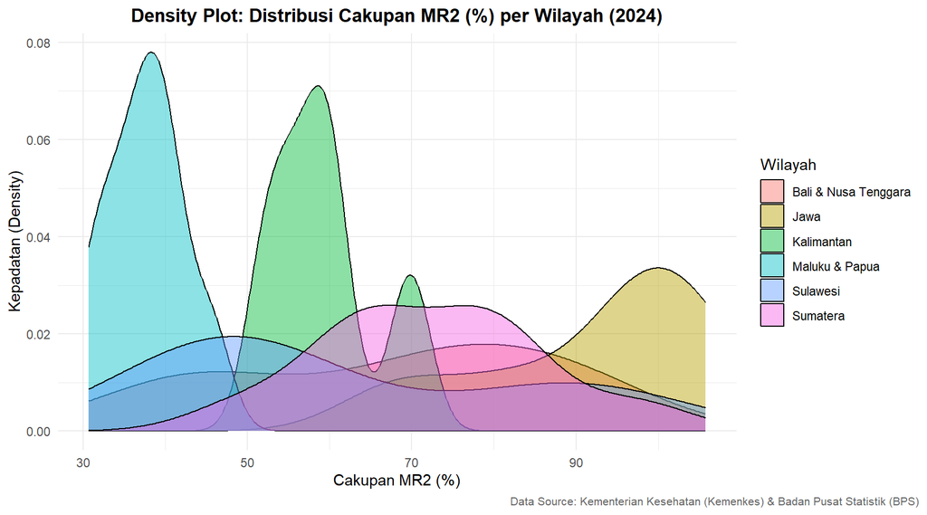

```r
density_plot <- ggplot(data, aes(x = `Cakupan MR2 %`, fill = `Pulau/Wilayah`)) +
  geom_density(alpha = 0.45) +
  theme_minimal() +
  labs(
    title = "Density Plot: Distribusi Cakupan MR2 (%) per Wilayah (2024)",
    x     = "Cakupan MR2 (%)",
    y     = "Kepadatan (Density)",
    fill  = "Wilayah",
    caption = "Data Source: Kementerian Kesehatan (Kemenkes) & Badan Pusat Statistik (BPS)"
  ) +
  theme(
    plot.title = element_text(hjust = 0.5, face = "bold", size = 13),
    plot.caption          = element_text(hjust = 1, size = 8, color = "gray40"),
    plot.caption.position = "plot"
  )

density_plot
```

### Interpretasi Density Plot

**Statistik Deskriptif:** Grafik ini memperlihatkan bagaimana distribusi nilai cakupan imunisasi pada masing-masing wilayah. Setiap warna mewakili wilayah tertentu sehingga memudahkan untuk melihat apakah suatu wilayah memiliki tingkat cakupan imunisasi yang lebih tinggi atau lebih rendah dibanding wilayah lainnya.

**Statistik Inferensia:** Jika kurva pada suatu wilayah berada lebih ke kanan, maka wilayah tersebut cenderung memiliki cakupan imunisasi yang lebih tinggi. Sebaliknya, jika kurva lebih ke kiri, maka cakupan imunisasi di wilayah tersebut relatif lebih rendah.

## 5. Boxplot

Dari data tersebut akan disajikan visualisasi data dalam bentuk Boxplot. Berikut terlampir hasil visualisasi **Sebaran Jumlah Kasus Campak per Wilayah**:

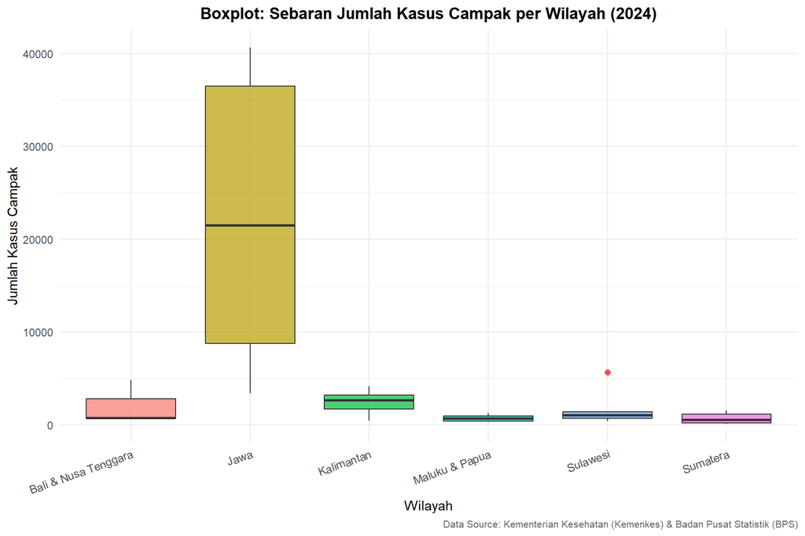

```r
boxplot_plot <- ggplot(data, aes(x = `Pulau/Wilayah`,
                                  y = `Jumlah Kasus Campak`,
                                  fill = `Pulau/Wilayah`)) +
  geom_boxplot(alpha = 0.7, outlier.color = "red", outlier.shape = 16, outlier.size = 2) +
  theme_minimal() +
  labs(
    title = "Boxplot: Sebaran Jumlah Kasus Campak per Wilayah (2024)",
    x     = "Wilayah",
    y     = "Jumlah Kasus Campak",
    fill  = "Wilayah",
    caption = "Data Source: Kementerian Kesehatan (Kemenkes) & Badan Pusat Statistik (BPS)"
  ) +
  theme(
    plot.title  = element_text(hjust = 0.5, face = "bold", size = 13),
    axis.text.x = element_text(angle = 20, hjust = 1, size = 9),
    legend.position = "none",
    plot.caption          = element_text(hjust = 1, size = 8, color = "gray40"),
    plot.caption.position = "plot"
  )

boxplot_plot
```

### Interpretasi Boxplot

**Statistik Deskriptif:** Dalam boxplot, kotak menunjukkan rentang kuartil pertama hingga kuartil ketiga, sedangkan garis di dalam kotak menunjukkan nilai median dari jumlah kasus. Titik merah menunjukkan outlier, yaitu nilai yang jauh lebih tinggi atau lebih rendah dibandingkan data lainnya.

**Statistik Inferensia:** Dalam boxplot, kotak menunjukkan rentang kuartil pertama hingga kuartil ketiga, sedangkan garis di dalam kotak menunjukkan nilai median dari jumlah kasus. Titik merah menunjukkan outlier, yaitu nilai yang jauh lebih tinggi atau lebih rendah dibandingkan data lainnya.

## Tabel Rekapitulasi Statistik Deskriptif

```r
modus <- function(x){
  frek <- table(x)
  if(max(frek) == 1){
    return("Tidak ada modus")
  } else {
    return(as.numeric(names(frek[frek == max(frek)])))
  }
}

hasil <- data.frame(
  Statistik    = c("Mean","Median","Modus","Minimum","Maximum",
                   "Range","Varians","Standar Deviasi","Q1","Q3"),
  Cakupan_MR2  = c(
    mean(data$`Cakupan MR2 %`),
    median(data$`Cakupan MR2 %`),
    modus(data$`Cakupan MR2 %`),
    min(data$`Cakupan MR2 %`),
    max(data$`Cakupan MR2 %`),
    diff(range(data$`Cakupan MR2 %`)),
    var(data$`Cakupan MR2 %`),
    sd(data$`Cakupan MR2 %`),
    quantile(data$`Cakupan MR2 %`, 0.25),
    quantile(data$`Cakupan MR2 %`, 0.75)
  ),
  Kasus_Campak = c(
    mean(data$`Jumlah Kasus Campak`),
    median(data$`Jumlah Kasus Campak`),
    modus(data$`Jumlah Kasus Campak`),
    min(data$`Jumlah Kasus Campak`),
    max(data$`Jumlah Kasus Campak`),
    diff(range(data$`Jumlah Kasus Campak`)),
    var(data$`Jumlah Kasus Campak`),
    sd(data$`Jumlah Kasus Campak`),
    quantile(data$`Jumlah Kasus Campak`, 0.25),
    quantile(data$`Jumlah Kasus Campak`, 0.75)
  )
)

print(hasil)
```

```
##          Statistik      Cakupan_MR2     Kasus_Campak
## 1             Mean 64.3957894736842 4584.97368421053
## 2           Median           62.625           1118.5
## 3            Modus  Tidak ada modus  Tidak ada modus
## 4          Minimum            30.65               89
## 5          Maximum           105.79            40635
## 6            Range            75.14            40546
## 7          Varians 470.607354765292  98374185.215505
## 8  Standar Deviasi 21.6934864594258 9918.37613803313
## 9               Q1           46.025            472.5
## 10              Q3           81.555          3068.75
```